# Model data

Weksi Budiaji, Agung Satrio Wicaksono

2025-09-10

### 1. Pendahuluan

Dalam perancangan basis data, kita membutuhkan sebuah kerangka atau model untuk menggambarkan data beserta hubungannya. Data model berfungsi sebagai alat konseptual untuk mendeskripsikan **data, hubungan antar data (relationship), semantik data, dan kendala (constraint)** yang berlaku. Secara umum, terdapat dua model utama yang digunakan, yaitu **Entity Relationship (ER) Model** dan **Relational Model**. Keduanya memiliki cara representasi yang berbeda, namun sama-sama bertujuan untuk mempermudah desain basis data.

### 2. Entity Relationship (ER) Model

Entity Relationship Model (ER Model) adalah salah satu pendekatan yang digunakan untuk merancang **Entity Relationship Diagram (ERD)** dalam basis data. Pada dasarnya, sebuah basis data dapat dimodelkan sebagai kumpulan **entitas** dan **relasi antar entitas**, di mana setiap entitas memiliki atribut yang menjelaskannya.

#### 2.1 Definisi Entitas dan Atribut

Entitas adalah objek yang dapat dibedakan dengan objek lainnya, baik bersifat konkret (misalnya: mahasiswa, dosen, buku) maupun abstrak (misalnya: pinjaman, jadwal). Dalam ERD, entitas digambarkan dengan **persegi panjang**. Contoh Entitas dalam sistem akademik: Mahasiswa, Dosen, Mata Kuliah sedangkan dalam sistem sekolah: Murid, Guru, Project. Entity Set adalah sekelompok entitas yang sejenis dalam ruang lingkup yang sama, contoh: Semua Mahasiswa di suatu universitas, Semua Nasabah di sebuah bank, Semua Customer di sebuah toko. Entity Set sering digambarkan dalam bentuk tabel, di mana setiap baris (row) merepresentasikan satu entitas.

Atribut adalah karakteristik atau properti yang mendeskripsikan suatu entitas. Dalam ERD, atribut digambarkan dengan **elips**, contoh: Mahasiswa (NIM, Nama, Alamat), Dosen (NIP, Nama, NIDN), Mata Kuliah (Kode MK, Nama MK), Customer (Customer ID, Customer Name, Customer Street, Customer City). Setiap atribut memiliki nilai (value), Contoh: Customer Name = “John”. Domain atau Value Set adalah batasan nilai yang diperbolehkan bagi atribut tertentu, Contoh: Customer ID maksimal 3 digit angka, Nama: tipe varchar(50), Balance: bilangan numerik dengan batas tertentu.

Jenis-Jenis Atribut terdiria atas Simple dan Composite Attribute. Simple Attribute yaitu atribute tidak dapat dipecah lagi, contoh: Student Number, Birthdate. Composite Attribute adalah atribut yang dapat dipecah menjadi atribut yang lebih kecil misalnya Name dipecah menjadi First Name, Last Name. Jenis atribute juga dapat dibedakan menjadi Single-Valued dan Multi-Valued Attribute Single-Valued Attribute yaitu atribut yang hanya memiliki satu nilai untuk tiap entitas, contoh: Birthdate, Student Number. Multi-Valued Attribute dapat memiliki lebih dari satu nilai untuk satu entitas, contoh: Phone Number (bisa lebih dari satu), Hobi. Dalam ERD, multi-valued attribute digambarkan dengan **elips ganda**. Derived Attribute (Atribut Turunan) juga dapat muncul yaitu atribut yang nilainya diperoleh dari perhitungan atribut lain, contoh: Umur dihitung dari Birthdate. Dalam ERD, digambarkan dengan **elips garis putus-putus**. Kelebihan dari derived atribute adalah tidak perlu terus-menerus diupdate, cukup dihitung saat diperlukan.

#### 2.2 Relasi Antar Entitas

Relasi adalah hubungan antara dua atau lebih entitas. Relasi menunjukkan bagaimana satu entitas berhubungan dengan entitas lainnya. Relasi biasanya dinyatakan dengan kata kerja, sedangkan entitas dengan kata benda. Contoh: Karyawan bekerja di Departemen, Siswa mendaftar di Kursus. Hubungan dituliskan dengan kata kerja, misalnya: bekerja di, memiliki, mendaftar di. Jika entitas digambarkan dengan persegi panjang ,relasi digambarkan dengan **belah ketupat (diamond)**.

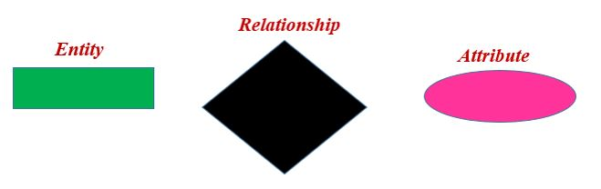

ER representation

Derajat relasi (Degree of Relationship) menunjukkan jumlah himpunan entitas yang terlibat dalam suatu relasi. **Unary Relationship (Derajat 1)** adalah relasi yang melibatkan satu himpunan entitas dengan dirinya sendiri. Contoh: Manusia menikah dengan Manusia, Employee mensupervisi Employee lain. **Binary Relationship (Derajat 2)** yaitu relasi yang melibatkan dua himpunan entitas. Contoh: Employee memiliki ID Card, Employee bekerja di Department, Book memiliki Author. **Ternary Relationship (Derajat 3)** merupakan relasi yang melibatkan tiga himpunan entitas, misalnya: Dokter memberikan resep (obat) kepada Pasien. Relasi ini menghubungkan tiga entitas: Dokter, Pasien, dan Obat.

**Kardinalitas** menunjukkan jumlah maksimum entitas yang dapat berelasi dengan entitas pada himpunan entitas lain. Kardinalitas paling sering digunakan pada relasi biner (derajat 2). Jenis Kardinalitas antara lain **One to One (1 : 1)** yaitu satu entitas di himpunan A berelasi dengan tepat satu entitas di himpunan B, dan sebaliknya, contoh: Employee memiliki tepat satu ID Card. **One to Many (1 : N)** yaitu satu entitas di himpunan A berelasi dengan banyak entitas di himpunan B, tetapi entitas B hanya terkait dengan satu entitas A. Contoh: Customer dapat melakukan banyak Order, tetapi satu Order hanya dimiliki oleh satu Customer. **Many to One (N : 1)** dengan banyak entitas di himpunan A berelasi dengan satu entitas di himpunan B, contoh: Banyak Employee bekerja di satu Department. **Many to Many (M : N)** yaitu banyak entitas di himpunan A dapat berelasi dengan banyak entitas di himpunan B, misalnya: Satu Author dapat menulis banyak buku dan Satu buku dapat ditulis oleh banyak Author.

#### 2.3 Entity Relationship Diagram (ERD)

Entity Relationship Diagram (ERD) adalah model konseptual yang digunakan untuk menggambarkan struktur logis dari basis data dalam bentuk grafis. Dengan ERD, kita dapat memahami hubungan antar entitas, atribut, serta bagaimana data saling berhubungan dalam suatu sistem. Dalam ERD, terdapat beberapa simbol yang umum digunakan:

- **Entitas**: digambarkan dengan persegi panjang (kata benda, misalnya Mahasiswa, Dosen, Mata Kuliah).
- **Atribut**: digambarkan dengan elips (kata benda, misalnya nama, alamat).
- **Elips berganda** → atribut multivalue.
- **Elips terputus** → atribut turunan (derived).
- **Atribut bergaris bawah** → primary key.
- **Relasi**: digambarkan dengan belah ketupat (kata kerja, misalnya mengambil, membimbing).
- **Garis**: penghubung antara entitas, atribut, dan relasi.

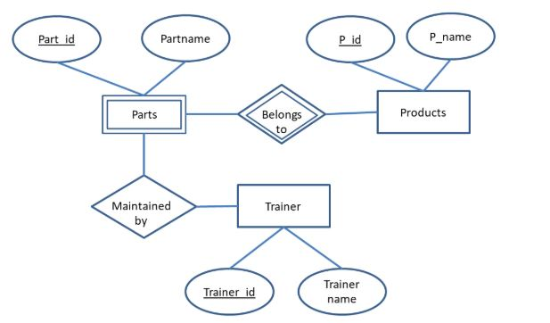

ER example

Langkah-Langkah Membuat ERD:

1. Identifikasi entitas: Menentukan objek-objek utama dalam sistem (contoh: Mahasiswa, Dosen, Mata Kuliah).
2. Identifikasi relasi: Menentukan hubungan antar entitas (contoh: Dosen *membimbing* Mahasiswa, Mahasiswa *mengambil* Mata Kuliah).
3. Menambahkan atribut: Memberikan informasi tambahan pada setiap entitas dan menentukan key (contoh: Mahasiswa memiliki NIM, Nama, Alamat).
4. Menggambar ERD lengkap: Memasukkan entitas, atribut, relasi, serta garis penghubung.
5. Review dan validasi: Mengecek kembali apakah desain ERD sesuai dengan kebutuhan logis basis data.

Contoh-Contoh ERD:

1. ERD Sederhana -> Entitas: Student – College, Relasi: Student study in College. Atribut untuk Student: StudentID (primary key), Nama, Alamat. Atribut untuk College: CollegeID (primary key), Nama.
2. ERD dengan Entitas Lemah ->Entitas: Produk (strong), Parts (weak), Trainer, Relasi: Produk memiliki Parts, Parts di-maintain Trainer. Kunci: ProdukID, PartID, TrainerID
3. ERD dengan Atribut Khusus -> Multi Value Attribute: Student memiliki Phone Number lebih dari satu, Derived Attribute: Age dihitung dari Date of Birth, Composite Attribute misalnya Nama dibuat First Name, Middle Name, Last Name.
4. Unary Relationship -> Entitas: Employee, Relasi: Employee works for Employee. Deskripsi: Seorang employee bisa menjadi manajer, dan yang lain adalah bawahan.
5. Relasi dengan Atribut -> Entitas: Employee – Department, Relasi: Employee works in Department. Atribut Relasi: Since (tanggal mulai bekerja).

#### 2.4 Varian Entitas dalam Entity Relationship Diagram (ERD)

Dalam ERD, entitas merupakan objek utama yang merepresentasikan data. Selama ini kita mengenal **entitas kuat (strong entity)** sebagai bentuk dasar. Namun, ada beberapa varian entitas lain yang penting dipahami, yaitu:

1. Entitas Lemah (Weak Entity)
2. Sub Entitas (Subclass Entity)

Entitas Kuat (Strong Entity) adalah entitas yang dapat berdiri sendiri, keberadaannya tidak bergantung pada entitas lain, contoh: Mahasiswa. Ciri-ciri:

- Memiliki **primary key** (contoh: NIM).
- Atribut lain bergantung pada primary key.
- Digambarkan dengan persegi panjang tunggal dalam ERD.

Entitas Lemah (Weak Entity) yaitu entitas yang keberadaannya bergantung pada entitas kuat melalui suatu relasi. Ciri-ciri:

- Tidak memiliki primary key sendiri.
- Digambarkan dengan persegi panjang ganda.
- Relasinya dengan entitas kuat digambarkan dengan belah ketupat ganda.
- Memiliki partial key (ditulis garis bawah putus-putus).

Contoh:

Entitas kuat: Dosen (primary key: Employee ID).

Entitas lemah: Tanggungan (Dependent).

Jika dosen tidak ada, maka data tanggungan ikut hilang.

Tanggungan dapat dibedakan dengan kode (misalnya Dependent Code), tetapi kode ini bukan primary key penuh → disebut **partial key**.

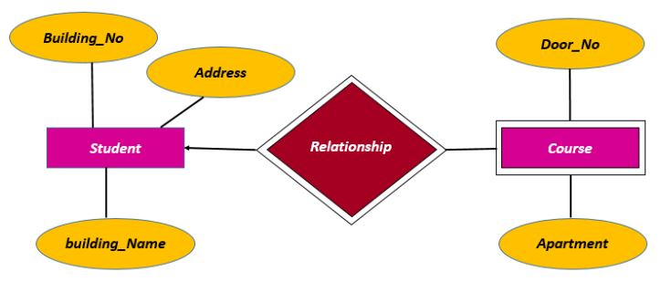

ER representation

Sub Entitas (Subclass Entity) adalah entitas hasil dekomposisi dari entitas yang lebih umum berdasarkan pengelompokan tertentu. Dasarnya merupakan Hasil dari generalisasi atau spesialisasi. Ciri-ciri:

- Mewarisi semua atribut dari entitas umum (superclass).
- Tidak memiliki primary key sendiri, melainkan menggunakan primary key dari entitas umum.

Contoh 1:

Entitas umum: Student (atribut: Registration Number, Name).

Sub entitas:

Postgraduate (atribut tambahan: Supervisor).

Undergraduate (atribut tambahan: Point).

Contoh 2:

Entitas umum: Karyawan.

Sub entitas:

Hourly Employee (atribut tambahan: Hourly Wages, Hours Worked).

Contract Employee (atribut tambahan: Contract ID).

#### 2.5 Variasi Relasi dalam Entity Relationship Diagram (ERD)

Dalam perancangan basis data, hubungan antar entitas tidak selalu sederhana. Selain relasi dasar, terdapat beberapa variasi atau jenis relasi khusus yang digunakan untuk menggambarkan kondisi nyata secara lebih tepat. Jenis relasi tersebut antara lain Relasi Ganda, Generalisasi, Spesialisasi, dan Agregasi.

**Relasi Ganda (Redundant Relation)** adalah relasi yang muncul lebih dari satu kali antara dua entitas. Alasannya karena Satu relasi saja tidak cukup menjelaskan hubungan di dunia nyata, sehingga diperlukan relasi tambahan. Contoh:

Entitas: Dosen dan Kuliah

Relasi:

Mengajar (dosen mengajar mata kuliah tertentu, dengan atribut tambahan seperti kode ruang dan waktu).

Menguasai (dosen menguasai materi dari mata kuliah tertentu, tanpa atribut tambahan).

**Catatan**: Dosen bisa menguasai mata kuliah tertentu tetapi belum tentu mendapat jatah mengajar mata kuliah tersebut.

**Generalisasi** merupakan Pendekatan bottom-up, di mana dua atau lebih entitas yang lebih spesifik digabung menjadi satu entitas yang lebih umum. Simbol: **segitiga terbalik**. Contoh: Entitas tingkat rendah (spesifik): Provinsi, Negara, Region. Digabung menjadi entitas umum: Location. Maknanya bahwa Entitas umum mewakili karakteristik yang dimiliki semua entitas khusus di bawahnya.

**Spesialisasi** adalah kebalikan dari generalisasi, dengan pendekatan top-down, yaitu satu entitas umum dipecah menjadi dua atau lebih entitas yang lebih spesifik. Simbolnya Sama dengan generalisasi. Contoh: Entitas umum: Student (punya atribut Registration Number dan Name). Entitas khusus: Postgraduate (punya atribut tambahan Supervisor), sedangkan Undergraduate (punya atribut tambahan Point). Maknanya Entitas khusus mewarisi atribut dari entitas umum, ditambah atribut spesifik masing-masing.

**Agregasi** adalah proses memperlakukan relasi antar dua entitas sebagai satu kesatuan baru, yang kemudian dapat berelasi dengan entitas lain. Tujuan dari agregasi untuk menggambarkan hubungan kompleks yang melibatkan lebih dari dua entitas.

Contoh 1:

Entitas: Project dan Department

Relasi: Sponsor

Agregasi: Relasi sponsor dianggap satu kesatuan, lalu berhubungan dengan entitas Employee (employee memonitor relasi sponsor tersebut).

Contoh 2:

Mahasiswa harus lulus Mata Kuliah A sebelum dapat mengikuti Praktikum A.

Relasi “Mahasiswa mempelajari Mata Kuliah” dianggap sebagai satu kesatuan, yang kemudian menjadi prasyarat relasi lain (Mahasiswa mengikuti Praktikum).

### 3. Relational Model

#### 3.1 Definisi

Relational model adalah salah satu model data yang digunakan untuk merepresentasikan basis data. Sebelumnya, perancangan database dapat dilakukan dengan **Entity Relationship Diagram (ERD)** yang menggambarkan entitas dan relasi antar entitas. Dalam relational model, hasil perancangan ERD tersebut kemudian diwujudkan dalam bentuk **tabel (relation)** yang lebih sederhana dan siap digunakan dalam implementasi database nyata.

- **Tabel** terdiri dari baris (row/tuple) dan kolom (attribute/field).
- **Baris (row/tuple)** merepresentasikan satu entitas tunggal.
- **Kolom (attribute/field)** menyatakan properti/karakteristik dari entitas.
- **Nama kolom** harus unik agar setiap atribut mudah diidentifikasi.
- Relational model mendukung operasi query menggunakan bahasa **SQL (Structured Query Language)**.

Model ini memungkinkan data tersimpan secara terstruktur, mudah diakses, serta konsisten.

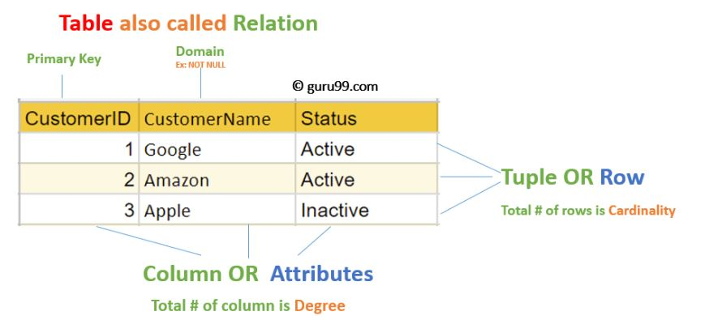

Relational model

#### 3.2 Istilah dalam Relational Model

Atribut: Kolom pada tabel. Melambangkan properti atau karakteristik entitas. Contoh: Tabel Dosen memiliki atribut NIP dan Nama.

Tabel (Relation): Bentuk penyimpanan data dalam relational model. Terdiri dari baris (row/tuple) dan kolom (attribute).

Tuple: Satu baris dalam tabel. Juga disebut record atau data item.

Degree: Jumlah atribut dalam satu tabel. Contoh: Tabel Dosen memiliki degree = 2 (NIP, Nama).

Cardinality: Jumlah tuple (row) dalam satu tabel. Contoh: Jika tabel Dosen memiliki 3 baris, maka cardinality = 3.

Relation Key: Satu atau lebih atribut yang digunakan untuk membedakan baris dalam tabel.

**Primary Key**: kunci utama yang unik.

**Foreign Key**: atribut yang berasal dari primary key tabel lain untuk membangun relasi.

Domain Atribut: Batasan nilai yang valid untuk suatu atribut. Contoh:

NIP: tipe data varchar(21) → maksimal 21 karakter.

Nama: tipe data varchar(50) → maksimal 50 karakter.

#### 3.3 Relasi Antar Tabel

Tabel-tabel dalam relational model saling berhubungan melalui primary key dan foreign key. Contoh:

Tabel **Mahasiswa** (StudentID)

Tabel **Mata Kuliah** (SubjectID)

Tabel **Skor** yang menghubungkan keduanya.

Relasi terbentuk karena:

StudentID (primary key dari Mahasiswa) menjadi foreign key di tabel Skor.

SubjectID (primary key dari Mata Kuliah) juga menjadi foreign key di tabel Skor.

Dengan demikian, tabel Skor berfungsi menghubungkan mahasiswa dengan mata kuliah dan nilai yang diperoleh.

Relational model dapat diwujudkan menggunakan Relational Database Management System (RDBMS) seperti: MySQL (open source, banyak digunakan untuk web development), PostgreSQL (open source, mendukung fitur lanjutan), SQL Server (berbayar, produk Microsoft). Meskipun tampilan graphical user interface berbeda, struktur tabel, query SQL, dan konsep relational model tetap sama.

#### 3.4 Kenapa Dipisah Menjadi Beberapa Tabel?

Data dipisahkan menjadi tabel-tabel berbeda untuk menghindari redundansi dan menjaga konsistensi data. Relational model memiliki beberapa keunggulan dibanding model data lain:

1. Kesederhanaan Representasi: Data direpresentasikan dalam bentuk tabel yang mudah dipahami oleh pengguna maupun programmer.
2. Konsistensi dan Integritas Data: Dengan adanya primary key dan foreign key, sistem dapat menjaga agar data tidak duplikat dan relasi antar tabel tetap valid.
3. Fleksibilitas dalam Query: Pengguna dapat melakukan berbagai macam query menggunakan SQL, misalnya untuk pencarian data, pengelompokan, hingga perhitungan.
4. Independensi Data:Struktur logis data (tabel) terpisah dari penyimpanan fisik, sehingga perubahan teknis tidak memengaruhi logika pemodelan.
5. Mendukung Normalisasi:Normalisasi membantu mengurangi redundansi dan meningkatkan efisiensi penyimpanan.
6. Kemudahan Ekspansi: Tabel baru dapat ditambahkan tanpa harus merombak keseluruhan sistem.

### 4. Perbedaan ER Model dan Relational Model

| Aspek | ER Model | Relational Model |
| --- | --- | --- |
| Representasi | Diagram (entitas, atribut, relasi) | Tabel |
| Simbol | Persegi panjang, elips, belah ketupat | Baris dan kolom |
| Fungsi | Mendesain basis data secara konseptual | Implementasi basis data secara logis |
| Contoh | *Customer* ↔︎ *Account* | Tabel *Customer*, *Account*, *Depositor* |

### 5. Penutup

Entity Relationship Model dan Relational Model merupakan dua pendekatan utama dalam pemodelan basis data. ER Model lebih fokus pada gambaran konseptual menggunakan diagram, sedangkan Relational Model lebih berorientasi pada implementasi nyata dalam bentuk tabel. Pemahaman kedua model ini sangat penting sebelum melangkah lebih jauh ke tahap implementasi dan pengelolaan basis data.

### Tugas

1. Identifikasi representasi di ERD berikut:

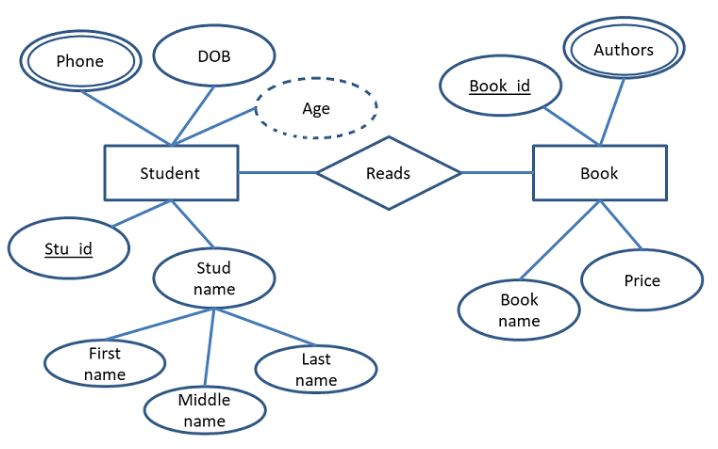

2. Buat relational model dari gambar ERD tersebut.